# PIMA Indian Diabetes Prediction using PYCARET

### UNIVARIATE ANALYSIS

```
array([[<matplotlib.axes._subplots.AxesSubplot object at 0x000001492262CB80>,
      dtype=object)
```

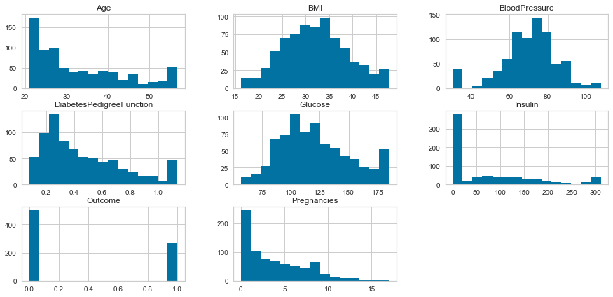

```python
df_diabetes.hist(bins=15,figsize=(15,7))
```

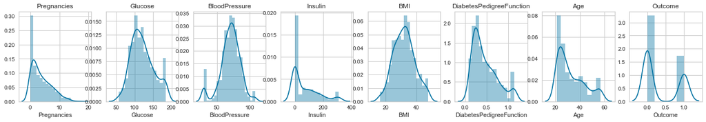

```python
# distribution

fig=plt.figure(figsize=(25,3))

for i in np.arange(0,8):
    plt.subplot(1,9,i+1,title=df_diabetes.columns[i])
    sns.distplot(df_diabetes[df_diabetes.columns[i]])
```

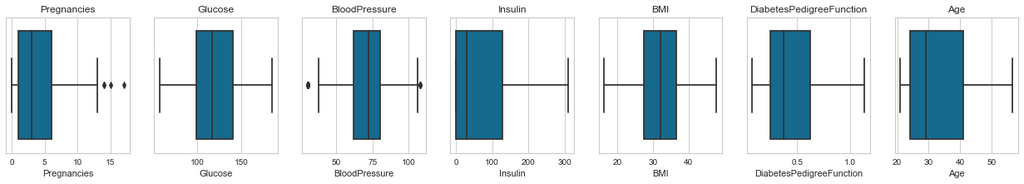

```python
# boxplot

fig=plt.figure(figsize=(25,3))

for i in np.arange(0,7):
    plt.subplot(1,8,i+1,title=df_diabetes.columns[i])
    sns.boxplot(df_diabetes[df_diabetes.columns[i]])
```

### BIVARIATE ANALYSIS

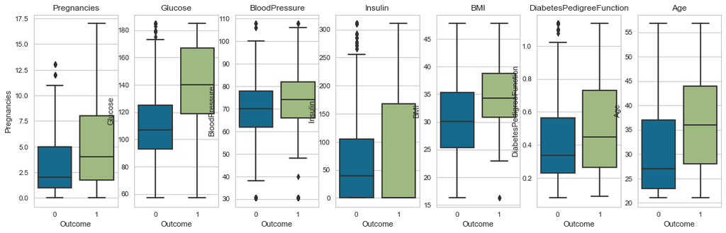

```python
fig=plt.figure(figsize=(20,5))

for i in np.arange(0,7):
    plt.subplot(1,8,i+1,title=df_diabetes.columns[i])
    sns.boxplot(y = df_diabetes.columns[i] ,x='Outcome', data = df_diabetes)
```

### PAIR PLOTS

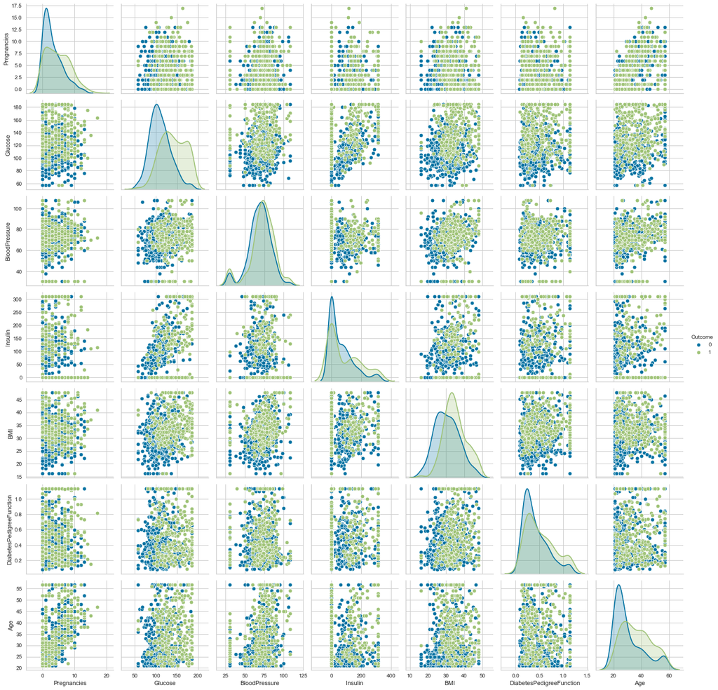

```python
plt.figure(figsize = (10,10))
sns.pairplot(df_diabetes ,hue ='Outcome')
```

```python
#### number pregnancies seem to have an effect on the outcome
```

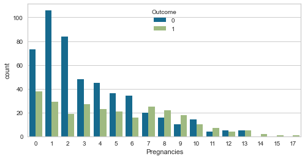

```python
plt.figure(figsize = (8,4))
sns.countplot(x='Pregnancies',hue='Outcome',data=df_diabetes)
```

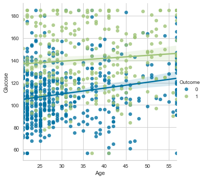

```python
plt.figure(figsize = (8,4))
sns.lmplot(y='Glucose',x = 'Age', hue='Outcome',data=df_diabetes)
```

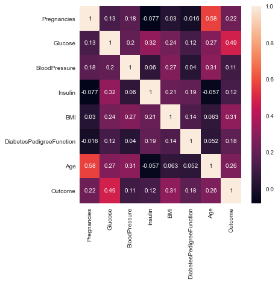

```python
#CORELATION BETWEEN ALL THE NUMERICAL FACTORS
## the plot has no noticable corellations as revealed by the scatter plots

plt.figure(figsize = (6,6))
sns.heatmap(df_diabetes.corr(),annot = True)
```

```python
### Correlation values plotted
```

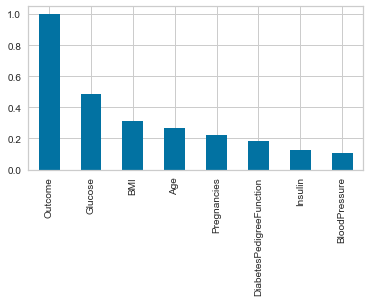

```python
plt.figure(figsize=(6,3))
df_diabetes.corr()['Outcome'].sort_values(ascending = False).plot(kind='bar')
```

### Checking the correlation with VIF

```python
# Check for the VIF values of the feature variables.
from statsmodels.stats.outliers_influence import variance_inflation_factor
import statsmodels.api as sm
```

```python
# Create a dataframe that will contain the names of all the feature variables and their respective VIFs
vif = pd.DataFrame()
vif['Features'] = df_diabetes.columns
vif['VIF'] = [variance_inflation_factor(df_diabetes.values, i) for i in range(df_diabetes.shape[1])]
vif['VIF'] = round(vif['VIF'], 2)
vif = vif.sort_values(by = "VIF", ascending = False)
vif
```

|  | Features | VIF |
| --- | --- | --- |
| 2 | BloodPressure | 24.88 |
| 4 | BMI | 21.59 |
| 1 | Glucose | 21.27 |
| 6 | Age | 16.85 |
| 5 | DiabetesPedigreeFunction | 3.87 |
| 0 | Pregnancies | 3.52 |
| 7 | Outcome | 1.99 |
| 3 | Insulin | 1.91 |

#### We find many parameters to be closely related not a surprise since one parameter affects another or appear together.

#### We deal with this when we do the setup in PYCARET

### Learnings from EDA

1) Data clearly shows a linear relation ship with outcome for Glucose , BMI , Age , Pregnancies and to a lesser extent with blood Pressure. The correlation plot also lists these columns as the top four.

2) Glucose emerges as the most importanct factor. No surprise since diabates is detected confidently only with glucose numbers even in a clinical setting.

3) At Younger Ages even a lesser Glucose Number leads to positive conversions.This Group Can be Targeted Early for intervensions

4) We should probably work towards glucose ranges for different ages groups instead of a single number to identify cases earlier.

#### Modelling with PYCARET

```python
data = df_diabetes.sample(frac=0.8, random_state=786)
data_unseen = df_diabetes.drop(data.index)

data.reset_index(drop=True, inplace=True)
data_unseen.reset_index(drop=True, inplace=True)

print('Data for Modeling: ' + str(data.shape))
print('Unseen Data For Predictions: ' + str(data_unseen.shape))
```

```
Data for Modeling: (614, 8)
Unseen Data For Predictions: (154, 8)
```

```python
from pycaret.classification  import *

clf102 = setup(data = data, target ='Outcome', session_id=123,
                  normalize = True,
                  transformation = True,
                  remove_multicollinearity = True,
                  numeric_features = ['Pregnancies'],
                  fix_imbalance = True)
```

```
Setup Succesfully Completed!
```

|  | Description | Value |
| --- | --- | --- |
| 0 | session_id | 123 |
| 1 | Target Type | Binary |
| 2 | Label Encoded | 0: 0, 1: 1 |
| 3 | Original Data | (614, 8) |
| 4 | Missing Values | False |
| 5 | Numeric Features | 7 |
| 6 | Categorical Features | 0 |
| 7 | Ordinal Features | False |
| 8 | High Cardinality Features | False |
| 9 | High Cardinality Method | None |
| 10 | Sampled Data | (614, 8) |
| 11 | Transformed Train Set | (429, 7) |
| 12 | Transformed Test Set | (185, 7) |
| 13 | Numeric Imputer | mean |
| 14 | Categorical Imputer | constant |
| 15 | Normalize | True |
| 16 | Normalize Method | zscore |
| 17 | Transformation | True |
| 18 | Transformation Method | yeo-johnson |
| 19 | PCA | False |
| 20 | PCA Method | None |
| 21 | PCA Components | None |
| 22 | Ignore Low Variance | False |
| 23 | Combine Rare Levels | False |
| 24 | Rare Level Threshold | None |
| 25 | Numeric Binning | False |
| 26 | Remove Outliers | False |
| 27 | Outliers Threshold | None |
| 28 | Remove Multicollinearity | True |
| 29 | Multicollinearity Threshold | 0.900000 |
| 30 | Clustering | False |
| 31 | Clustering Iteration | None |
| 32 | Polynomial Features | False |
| 33 | Polynomial Degree | None |
| 34 | Trignometry Features | False |
| 35 | Polynomial Threshold | None |
| 36 | Group Features | False |
| 37 | Feature Selection | False |
| 38 | Features Selection Threshold | None |
| 39 | Feature Interaction | False |
| 40 | Feature Ratio | False |
| 41 | Interaction Threshold | None |
| 42 | Fix Imbalance | True |
| 43 | Fix Imbalance Method | SMOTE |

```python
best = compare_models(sort = 'AUC',n_select = 3)
```

|  | Model | Accuracy | AUC | Recall | Prec. | F1 | Kappa | MCC | TT (Sec) |
| --- | --- | --- | --- | --- | --- | --- | --- | --- | --- |
| 0 | Logistic Regression | 0.7368 | 0.8260 | 0.7129 | 0.6011 | 0.6446 | 0.4391 | 0.4522 | 0.0065 |
| 1 | Linear Discriminant Analysis | 0.7251 | 0.8254 | 0.7129 | 0.5831 | 0.6341 | 0.4184 | 0.4329 | 0.0034 |
| 2 | Naive Bayes | 0.7227 | 0.8082 | 0.7262 | 0.5825 | 0.6377 | 0.4189 | 0.4352 | 0.0023 |
| 3 | Gradient Boosting Classifier | 0.7344 | 0.8049 | 0.6714 | 0.6115 | 0.6260 | 0.4237 | 0.4373 | 0.1053 |
| 4 | Quadratic Discriminant Analysis | 0.7064 | 0.7953 | 0.6581 | 0.5592 | 0.5970 | 0.3692 | 0.3807 | 0.0028 |
| 5 | CatBoost Classifier | 0.7111 | 0.7922 | 0.6305 | 0.5774 | 0.5909 | 0.3707 | 0.3800 | 1.5383 |
| 6 | Light Gradient Boosting Machine | 0.7272 | 0.7845 | 0.6024 | 0.5971 | 0.5912 | 0.3888 | 0.3938 | 0.0608 |
| 7 | Ada Boost Classifier | 0.7228 | 0.7795 | 0.6452 | 0.5959 | 0.6092 | 0.3978 | 0.4066 | 0.0757 |
| 8 | Extra Trees Classifier | 0.7204 | 0.7780 | 0.5895 | 0.5992 | 0.5839 | 0.3754 | 0.3824 | 0.1191 |
| 9 | Extreme Gradient Boosting | 0.6901 | 0.7679 | 0.5757 | 0.5581 | 0.5549 | 0.3199 | 0.3292 | 0.0566 |
| 10 | Random Forest Classifier | 0.7273 | 0.7552 | 0.5695 | 0.6187 | 0.5828 | 0.3832 | 0.3911 | 0.0244 |
| 11 | K Neighbors Classifier | 0.6760 | 0.7215 | 0.6300 | 0.5330 | 0.5708 | 0.3161 | 0.3234 | 0.0024 |
| 12 | Decision Tree Classifier | 0.6153 | 0.5767 | 0.4548 | 0.4526 | 0.4503 | 0.1563 | 0.1571 | 0.0038 |
| 13 | SVM - Linear Kernel | 0.6879 | 0.0000 | 0.6790 | 0.5429 | 0.5953 | 0.3481 | 0.3628 | 0.0036 |
| 14 | Ridge Classifier | 0.7251 | 0.0000 | 0.7129 | 0.5831 | 0.6341 | 0.4184 | 0.4329 | 0.0038 |

```python
print(best)
```

```
[LogisticRegression(C=1.0, class_weight=None, dual=False, fit_intercept=True,
                   intercept_scaling=1, l1_ratio=None, max_iter=100,
                   multi_class='auto', n_jobs=None, penalty='l2',
                   random_state=123, solver='lbfgs', tol=0.0001, verbose=0,
                   warm_start=False), LinearDiscriminantAnalysis(n_components=None, priors=None, shrinkage=None,
                           solver='svd', store_covariance=False, tol=0.0001), GaussianNB(priors=None, var_smoothing=1e-09)]
```

##### Create a Linear Regression Model one of the top 3 with maximum accuracy

```python
lr = create_model('lr')
```

|  | Accuracy | AUC | Recall | Prec. | F1 | Kappa | MCC |
| --- | --- | --- | --- | --- | --- | --- | --- |
| 0 | 0.8140 | 0.8643 | 0.7333 | 0.7333 | 0.7333 | 0.5905 | 0.5905 |
| 1 | 0.6512 | 0.7571 | 0.4667 | 0.5000 | 0.4828 | 0.2201 | 0.2204 |
| 2 | 0.7209 | 0.8619 | 0.9333 | 0.5600 | 0.7000 | 0.4680 | 0.5221 |
| 3 | 0.6977 | 0.7690 | 0.6000 | 0.5625 | 0.5806 | 0.3447 | 0.3451 |
| 4 | 0.8140 | 0.9452 | 1.0000 | 0.6522 | 0.7895 | 0.6356 | 0.6825 |
| 5 | 0.8140 | 0.9000 | 0.8000 | 0.7059 | 0.7500 | 0.6028 | 0.6058 |
| 6 | 0.6512 | 0.7571 | 0.6667 | 0.5000 | 0.5714 | 0.2873 | 0.2958 |
| 7 | 0.6512 | 0.6946 | 0.6429 | 0.4737 | 0.5455 | 0.2728 | 0.2812 |
| 8 | 0.7442 | 0.8030 | 0.5000 | 0.6364 | 0.5600 | 0.3833 | 0.3889 |
| 9 | 0.8095 | 0.9082 | 0.7857 | 0.6875 | 0.7333 | 0.5862 | 0.5894 |
| Mean | 0.7368 | 0.8260 | 0.7129 | 0.6011 | 0.6446 | 0.4391 | 0.4522 |
| SD | 0.0685 | 0.0773 | 0.1643 | 0.0892 | 0.1018 | 0.1488 | 0.1557 |

```python
tuned_lr = tune_model(lr , optimize = 'AUC')
```

|  | Accuracy | AUC | Recall | Prec. | F1 | Kappa | MCC |
| --- | --- | --- | --- | --- | --- | --- | --- |
| 0 | 0.8140 | 0.8643 | 0.7333 | 0.7333 | 0.7333 | 0.5905 | 0.5905 |
| 1 | 0.6512 | 0.7571 | 0.4667 | 0.5000 | 0.4828 | 0.2201 | 0.2204 |
| 2 | 0.7209 | 0.8619 | 0.9333 | 0.5600 | 0.7000 | 0.4680 | 0.5221 |
| 3 | 0.6977 | 0.7690 | 0.6000 | 0.5625 | 0.5806 | 0.3447 | 0.3451 |
| 4 | 0.8140 | 0.9452 | 1.0000 | 0.6522 | 0.7895 | 0.6356 | 0.6825 |
| 5 | 0.8140 | 0.9000 | 0.8000 | 0.7059 | 0.7500 | 0.6028 | 0.6058 |
| 6 | 0.6512 | 0.7571 | 0.6667 | 0.5000 | 0.5714 | 0.2873 | 0.2958 |
| 7 | 0.6512 | 0.6946 | 0.6429 | 0.4737 | 0.5455 | 0.2728 | 0.2812 |
| 8 | 0.7442 | 0.8030 | 0.5000 | 0.6364 | 0.5600 | 0.3833 | 0.3889 |
| 9 | 0.8095 | 0.9107 | 0.7857 | 0.6875 | 0.7333 | 0.5862 | 0.5894 |
| Mean | 0.7368 | 0.8263 | 0.7129 | 0.6011 | 0.6446 | 0.4391 | 0.4522 |
| SD | 0.0685 | 0.0776 | 0.1643 | 0.0892 | 0.1018 | 0.1488 | 0.1557 |

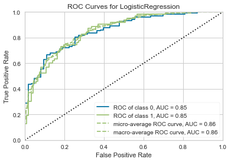

```python
plot_model(tuned_lr, plot = 'auc')
```

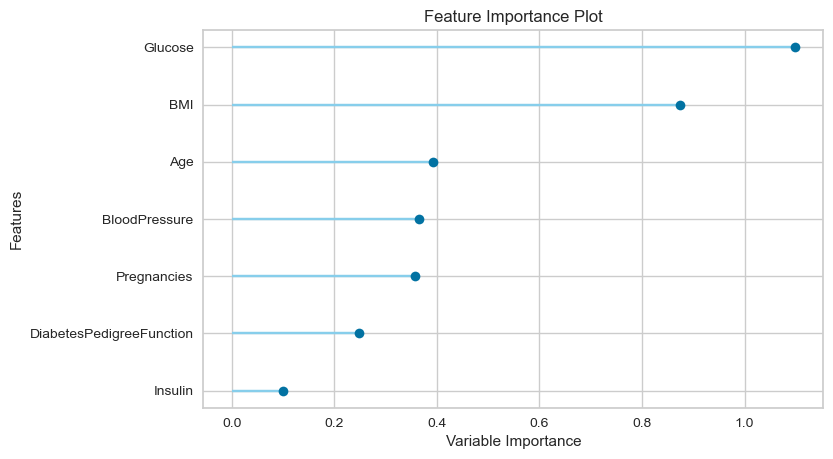

```python
plot_model(tuned_lr, plot='feature')
```

##### Create a Naive Bayes Model one of the top 3 with maximum recall

```python
nb = create_model('nb')
```

|  | Accuracy | AUC | Recall | Prec. | F1 | Kappa | MCC |
| --- | --- | --- | --- | --- | --- | --- | --- |
| 0 | 0.7442 | 0.8857 | 0.7333 | 0.6111 | 0.6667 | 0.4619 | 0.4669 |
| 1 | 0.6744 | 0.7381 | 0.5333 | 0.5333 | 0.5333 | 0.2833 | 0.2833 |
| 2 | 0.6512 | 0.7976 | 0.8667 | 0.5000 | 0.6341 | 0.3438 | 0.3922 |
| 3 | 0.6977 | 0.7405 | 0.6000 | 0.5625 | 0.5806 | 0.3447 | 0.3451 |
| 4 | 0.7442 | 0.9000 | 0.9333 | 0.5833 | 0.7179 | 0.5057 | 0.5530 |
| 5 | 0.8372 | 0.9119 | 0.9333 | 0.7000 | 0.8000 | 0.6674 | 0.6871 |
| 6 | 0.6744 | 0.7310 | 0.7333 | 0.5238 | 0.6111 | 0.3442 | 0.3587 |
| 7 | 0.6744 | 0.7020 | 0.6429 | 0.5000 | 0.5625 | 0.3096 | 0.3158 |
| 8 | 0.7674 | 0.8030 | 0.5000 | 0.7000 | 0.5833 | 0.4282 | 0.4399 |
| 9 | 0.7619 | 0.8724 | 0.7857 | 0.6111 | 0.6875 | 0.5000 | 0.5103 |
| Mean | 0.7227 | 0.8082 | 0.7262 | 0.5825 | 0.6377 | 0.4189 | 0.4352 |
| SD | 0.0551 | 0.0750 | 0.1485 | 0.0701 | 0.0772 | 0.1117 | 0.1171 |

```python
tuned_nb = tune_model(nb , optimize = 'AUC')
```

|  | Accuracy | AUC | Recall | Prec. | F1 | Kappa | MCC |
| --- | --- | --- | --- | --- | --- | --- | --- |
| 0 | 0.7674 | 0.8786 | 0.7333 | 0.6471 | 0.6875 | 0.5035 | 0.5060 |
| 1 | 0.6279 | 0.7405 | 0.5333 | 0.4706 | 0.5000 | 0.2055 | 0.2066 |
| 2 | 0.6512 | 0.7905 | 0.8667 | 0.5000 | 0.6341 | 0.3438 | 0.3922 |
| 3 | 0.6744 | 0.7524 | 0.5333 | 0.5333 | 0.5333 | 0.2833 | 0.2833 |
| 4 | 0.7442 | 0.8857 | 0.9333 | 0.5833 | 0.7179 | 0.5057 | 0.5530 |
| 5 | 0.8140 | 0.9190 | 0.8667 | 0.6842 | 0.7647 | 0.6143 | 0.6261 |
| 6 | 0.6279 | 0.7333 | 0.6667 | 0.4762 | 0.5556 | 0.2505 | 0.2611 |
| 7 | 0.6512 | 0.6921 | 0.5714 | 0.4706 | 0.5161 | 0.2474 | 0.2502 |
| 8 | 0.7674 | 0.7956 | 0.5000 | 0.7000 | 0.5833 | 0.4282 | 0.4399 |
| 9 | 0.7381 | 0.8546 | 0.7143 | 0.5882 | 0.6452 | 0.4407 | 0.4459 |
| Mean | 0.7064 | 0.8042 | 0.6919 | 0.5654 | 0.6138 | 0.3823 | 0.3964 |
| SD | 0.0640 | 0.0725 | 0.1496 | 0.0843 | 0.0859 | 0.1294 | 0.1350 |

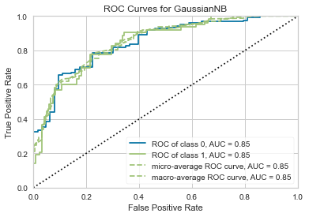

```python
plot_model(tuned_nb, plot = 'auc')
```

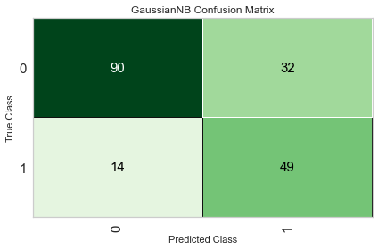

```python
plot_model(tuned_nb, plot='confusion_matrix')
```

#### Evaluating the linear Regression Model

```python
evaluate_model(tuned_lr)
```

#### Bagging the linear regression model since it has the best AUC

```python
bagged_lr = ensemble_model(tuned_lr)
```

|  | Accuracy | AUC | Recall | Prec. | F1 | Kappa | MCC |
| --- | --- | --- | --- | --- | --- | --- | --- |
| 0 | 0.8140 | 0.8667 | 0.8000 | 0.7059 | 0.7500 | 0.6028 | 0.6058 |
| 1 | 0.6512 | 0.7524 | 0.4667 | 0.5000 | 0.4828 | 0.2201 | 0.2204 |
| 2 | 0.6977 | 0.8667 | 0.9333 | 0.5385 | 0.6829 | 0.4313 | 0.4920 |
| 3 | 0.6977 | 0.7667 | 0.6000 | 0.5625 | 0.5806 | 0.3447 | 0.3451 |
| 4 | 0.8140 | 0.9405 | 1.0000 | 0.6522 | 0.7895 | 0.6356 | 0.6825 |
| 5 | 0.8140 | 0.9024 | 0.8000 | 0.7059 | 0.7500 | 0.6028 | 0.6058 |
| 6 | 0.6512 | 0.7452 | 0.6667 | 0.5000 | 0.5714 | 0.2873 | 0.2958 |
| 7 | 0.6512 | 0.6872 | 0.6429 | 0.4737 | 0.5455 | 0.2728 | 0.2812 |
| 8 | 0.7442 | 0.8030 | 0.5000 | 0.6364 | 0.5600 | 0.3833 | 0.3889 |
| 9 | 0.7857 | 0.9056 | 0.7143 | 0.6667 | 0.6897 | 0.5263 | 0.5270 |
| Mean | 0.7321 | 0.8236 | 0.7124 | 0.5942 | 0.6402 | 0.4307 | 0.4444 |
| SD | 0.0672 | 0.0799 | 0.1649 | 0.0847 | 0.0996 | 0.1449 | 0.1516 |

```python
evaluate_model(bagged_lr)
```

#### Finalizing the model to the bagged lr model.

```python
final_lr = finalize_model(bagged_lr)
```

```python
predict_model(final_lr)
```

|  | Model | Accuracy | AUC | Recall | Prec. | F1 | Kappa | MCC |
| --- | --- | --- | --- | --- | --- | --- | --- | --- |
| 0 | Bagging Classifier | 0.7622 | 0.8613 | 0.7778 | 0.6203 | 0.6901 | 0.5011 | 0.5096 |

|  | Pregnancies | Glucose | BloodPressure | Insulin | BMI | DiabetesPedigreeFunction | Age | Outcome | Label | Score |
| --- | --- | --- | --- | --- | --- | --- | --- | --- | --- | --- |
| 0 | 1.557900 | 0.128522 | 0.453544 | -0.942351 | -0.640516 | 0.464315 | 1.159325 | 0 | 1 | 0.5665 |
| 1 | -0.458097 | -0.299539 | 0.161227 | 0.916477 | 0.078674 | 0.994799 | -0.421354 | 0 | 0 | 0.3143 |
| 2 | 1.706043 | 0.293451 | 2.760688 | -0.942351 | 1.010581 | -1.151718 | 1.455126 | 0 | 1 | 0.6859 |
| 3 | 0.820865 | 1.301660 | -0.635442 | -0.942351 | -1.152273 | -1.231475 | 1.409511 | 1 | 1 | 0.7198 |
| 4 | -0.050673 | 1.327846 | -0.117631 | 0.751969 | -0.038603 | -0.666214 | -0.283817 | 1 | 1 | 0.6471 |
| ... | ... | ... | ... | ... | ... | ... | ... | ... | ... | ... |
| 180 | -0.924610 | -1.529349 | 0.161227 | 0.234351 | -0.276524 | 0.514734 | -1.208948 | 0 | 0 | 0.0551 |
| 181 | -0.924610 | -0.726936 | -0.879612 | -0.942351 | -0.980400 | 0.591969 | -1.385995 | 0 | 0 | 0.1038 |
| 182 | -0.924610 | -1.397815 | -0.251541 | -0.942351 | -2.124719 | 0.805091 | -0.421354 | 0 | 0 | 0.0338 |
| 183 | -0.924610 | -1.311083 | -0.382227 | -0.942351 | -0.794335 | -0.213904 | 0.087451 | 0 | 0 | 0.0969 |
| 184 | -0.050673 | 1.195774 | 0.305843 | 1.546608 | -0.038603 | 1.328092 | -0.283817 | 1 | 1 | 0.6840 |

185 rows × 10 columns

```python
print(final_lr)
```

```
BaggingClassifier(base_estimator=LogisticRegression(C=3.931,
                                                    class_weight='balanced',
                                                    dual=False,
                                                    fit_intercept=True,
                                                    intercept_scaling=1,
                                                    l1_ratio=None, max_iter=100,
                                                    multi_class='auto',
                                                    n_jobs=None, penalty='l2',
                                                    random_state=123,
                                                    solver='lbfgs', tol=0.0001,
                                                    verbose=0,
                                                    warm_start=False),
                  bootstrap=True, bootstrap_features=False, max_features=1.0,
                  max_samples=1.0, n_estimators=10, n_jobs=-1, oob_score=False,
                  random_state=123, verbose=0, warm_start=False)
```

```python
predict_lr = predict_model(bagged_lr)
```

|  | Model | Accuracy | AUC | Recall | Prec. | F1 | Kappa | MCC |
| --- | --- | --- | --- | --- | --- | --- | --- | --- |
| 0 | Bagging Classifier | 0.7676 | 0.8505 | 0.7143 | 0.6429 | 0.6767 | 0.496 | 0.4977 |

#### Predict on Unseen Data

```python
unseen_predictions = predict_model(final_lr, data=data_unseen)
unseen_predictions['Label'] = unseen_predictions['Label'].astype(int)
```

```python
unseen_predictions
```

|  | Pregnancies | Glucose | BloodPressure | Insulin | BMI | DiabetesPedigreeFunction | Age | Outcome | Label | Score |
| --- | --- | --- | --- | --- | --- | --- | --- | --- | --- | --- |
| 0 | 1 | 89.000000 | 66.000000 | 94.000000 | 28.1 | 0.167 | 21.000000 | 0 | 0 | 0.0424 |
| 1 | 5 | 116.000000 | 74.000000 | 0.000000 | 25.6 | 0.201 | 30.000000 | 0 | 0 | 0.2182 |
| 2 | 10 | 115.000000 | 30.393854 | 0.000000 | 35.3 | 0.134 | 29.000000 | 0 | 1 | 0.6096 |
| 3 | 1 | 184.839768 | 60.000000 | 310.287484 | 30.1 | 0.398 | 56.761348 | 1 | 1 | 0.8864 |
| 4 | 5 | 166.000000 | 72.000000 | 175.000000 | 25.8 | 0.587 | 51.000000 | 1 | 1 | 0.7757 |
| ... | ... | ... | ... | ... | ... | ... | ... | ... | ... | ... |
| 149 | 1 | 128.000000 | 88.000000 | 110.000000 | 36.5 | 1.057 | 37.000000 | 1 | 1 | 0.6643 |
| 150 | 1 | 106.000000 | 76.000000 | 0.000000 | 37.5 | 0.197 | 26.000000 | 0 | 0 | 0.2931 |
| 151 | 9 | 170.000000 | 74.000000 | 0.000000 | 44.0 | 0.403 | 43.000000 | 1 | 1 | 0.9667 |
| 152 | 5 | 121.000000 | 72.000000 | 112.000000 | 26.2 | 0.245 | 30.000000 | 0 | 0 | 0.2387 |
| 153 | 1 | 93.000000 | 70.000000 | 0.000000 | 30.4 | 0.315 | 23.000000 | 0 | 0 | 0.1062 |

154 rows × 10 columns

```python
from pycaret.utils import check_metric
check_metric(unseen_predictions.Outcome, unseen_predictions.Label, 'Recall')
```

```
0.8103
```

```python
check_metric(unseen_predictions.Outcome, unseen_predictions.Label, 'Precision')
```

```
0.746
```

```python
check_metric(unseen_predictions.Outcome, unseen_predictions.Label, 'Accuracy')
```

```
0.8247
```

```python
check_metric(unseen_predictions.Outcome, unseen_predictions.Label, 'AUC')
```

```
0.8218
```

```python
confusion_matrix(unseen_predictions.Outcome, unseen_predictions.Label)
```

```
array([[80, 16],
       [11, 47]], dtype=int64)
```

#### SAVE MODEL

```python
save_model(final_lr,'Final LR Model')
```

```
Transformation Pipeline and Model Succesfully Saved
```

```python
saved_final_lr = load_model('Final LR Model')
```

```
Transformation Pipeline and Model Successfully Loaded
```

#### The Performance of the model on the unseen data is almost similar to the test/train data sets.

#### Recall - 0.8103

#### Precision - 0.746

#### AUC - 0.8218

#### Accuracy - 0.8247

Recall is important in most heathcare models since we need to identify cases with the disease especially if the treatement options even if the disease is not found are harmless in the normal population. We should to try to also try to balance the precision since we cannot have too many False Positives ie people wrongly labelled as diabetics since it burdens the health care system.

The accuracy of this model on unseen data is around 83%

#### The feature importance plot lists the important features.

#### Linear Regression identifies the important featues which tallies with our eda results. We can confidently say that a linear relationship exists between these Columns and the model chosen finally was also a linear one for classification.

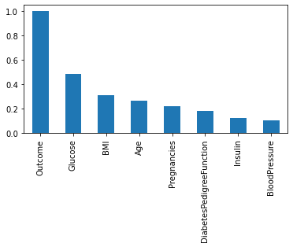

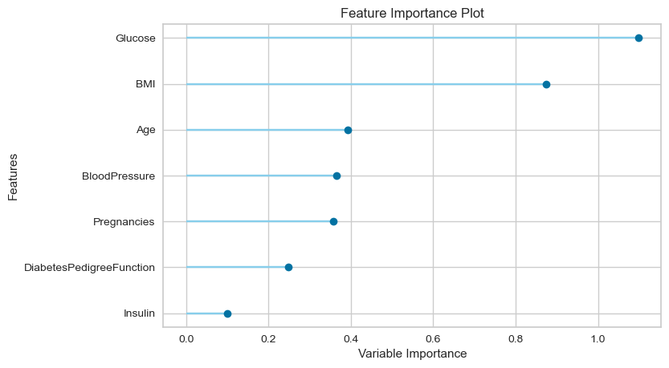